# QMM Group Project

# GPA vs Communication Skill Scatter plot

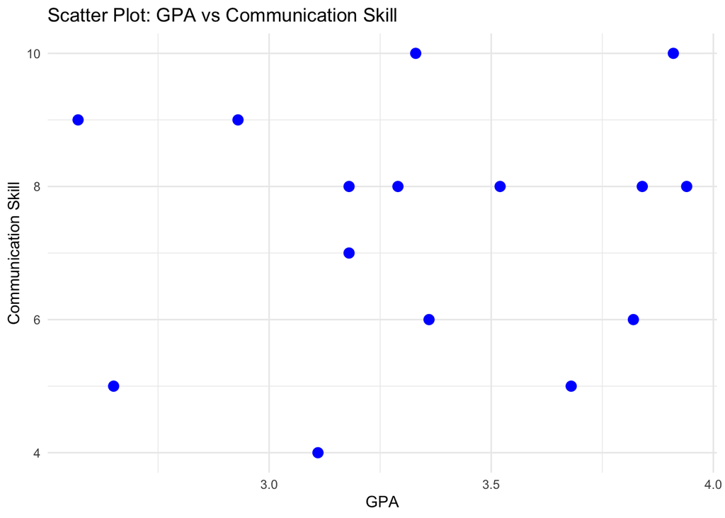

```r
# Create a scatter plot for GPA vs Communication Skill
ggplot(df, aes(x = GPA, y = Communication)) +
  geom_point(color = "blue", size = 3) +
  labs(x = "GPA", y = "Communication Skill", title = "Scatter Plot: GPA vs Communication Skill") +
  theme_minimal()
```

A scatter plot helps us see the relationship between GPA and communication skills. Each dot on the plot represents one student, showing their GPA on the x-axis and communication skill on the y-axis. If the dots form a clear pattern, like an upward trend, it means there’s a connection between the two factors, students with higher GPA may also have better communication skills. If the dots are spread out randomly, it means there’s no strong relationship. Scatter plot for GPA and communication skills, we can interpret that students with a GPA below 3 include one with low communication skills and another with better communication skills, showing that GPA doesn’t always predict communication ability. For students with a GPA above 3, some have strong communication skills, while others have lower communication skills, which shows a mix of abilities. Students who have both high GPA and strong communication skills are likely to perform well in both academics and teamwork. On the other hand, students with low GPA but high communication skills might still be valuable in group projects because they can collaborate effectively.

# GPA vs. Teamwork Skill Scatter Plot

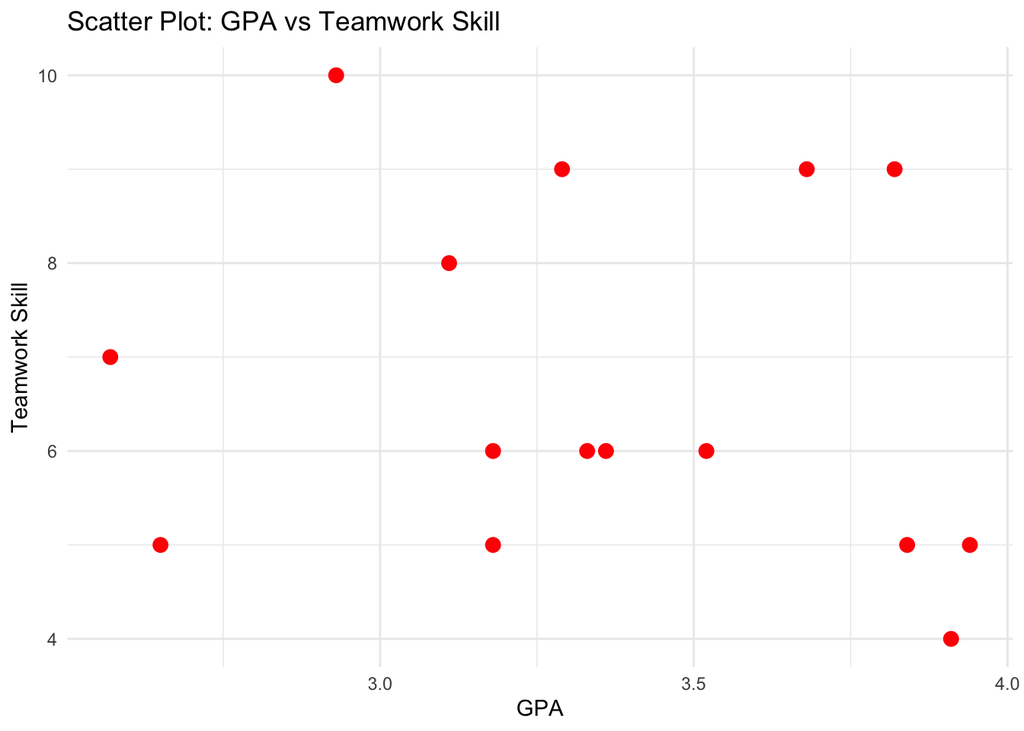

```r
# Create a scatter plot for GPA vs Teamwork
ggplot(df, aes(x = GPA, y = Teamwork)) +
  geom_point(color = "red", size = 3) +
  labs(x = "GPA", y = "Teamwork Skill", title = "Scatter Plot: GPA vs Teamwork Skill") +
  theme_minimal()
```

This plot compares GPA with teamwork ability. Here, if the dots are spread randomly with no clear upward or downward trend, it means GPA doesn’t strongly affect teamwork ability.

Some students with higher GPAs may have better teamwork scores, while others do not. This shows a mix of skills among the students.

# Communication Skill vs. Teamwork Skill Scatter Plot

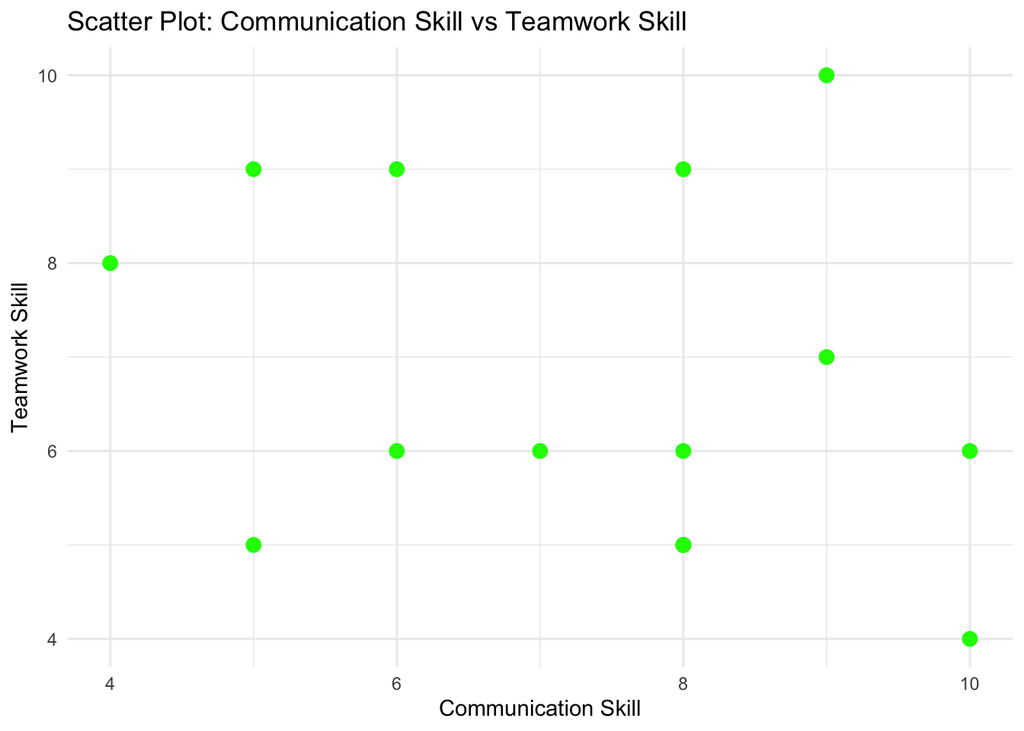

```r
# Create a scatter plot for Communication Skill vs Teamwork Skill
ggplot(df, aes(x = Communication, y = Teamwork)) +
  geom_point(color = "green", size = 3) +
  labs(x = "Communication Skill", y = "Teamwork Skill", title = "Scatter Plot: Communication Skill vs Teamwork Skill") +
  theme_minimal()
```

On the other hand, the GPA vs. Communication Skill and GPA vs. Teamwork Skill scatter plots show scattered points, indicating no strong connection between GPA and these skills. Most students are not grouped within a central range, showing that their performance levels vary widely. This happens because a high GPA reflects academic success but doesn’t always predict a student’s teamwork or communication skills. Some students with lower GPAs may have strong communication or teamwork abilities, while others with high GPAs may struggle in these areas. This shows that GPA alone doesn’t determine a student’s interpersonal or teamwork abilities.